# Seasonality

```r
library(stats)
suppressPackageStartupMessages(
  library(fpp2)
)
library(forecast)
suppressPackageStartupMessages(
  library(dynlm)
)
library(magrittr)
suppressPackageStartupMessages(
  library(tseries)
)
```

```r
L=read.csv('LaborForce.csv',header=T)
Labor = ts(L$LNU01327662,start=1992,frequency=12)
t = time(Labor)
model8=tslm(Labor~I(t*t)+t*cos(2*pi*t/13)+sin(2*pi*t/13))
```

# 2. Modeling and Forecasting Seasonality

**(a) Construct and test (by looking at the diagnostic statistics) a model with a full set of seasonal dummies.**

To estimate the seasoanl effect, we use a set of 11 seasonal dummies to indicate whether a particular measurement occured in February, March, etc. It is important to isolate the trend component to the seasonality estimation does not become biased.

```r
# regress Labor on linear trend plus full seasonal dummies
seasonal=tslm(Labor~trend+season)

# print out summary of model
summary(seasonal)
```

```
##
## Call:
## tslm(formula = Labor ~ trend + season)
##
## Residuals:
##      Min       1Q   Median       3Q      Max
## -1.00441 -0.37591 -0.02321  0.28539  1.07208
##
## Coefficients:
##               Estimate Std. Error  t value Pr(>|t|)
## (Intercept) 82.0213887  0.0932833  879.272  < 2e-16 ***
## trend       -0.0250217  0.0002499 -100.120  < 2e-16 ***
## season2      0.2107360  0.1186789    1.776  0.07673 .
## season3      0.2857576  0.1186797    2.408  0.01661 *
## season4      0.1572079  0.1186810    1.325  0.18623
## season5      0.1250867  0.1186829    1.054  0.29269
## season6     -0.4034631  0.1186852   -3.399  0.00076 ***
## season7     -0.6641557  0.1186881   -5.596 4.69e-08 ***
## season8     -0.6391341  0.1186915   -5.385 1.40e-07 ***
## season9     -0.0641124  0.1186955   -0.540  0.58947
## season10     0.1109093  0.1187000    0.934  0.35081
## season11     0.0716452  0.1187050    0.604  0.54656
## season12     0.0895240  0.1187105    0.754  0.45132
## ---
## Signif. codes:  0 '***' 0.001 '**' 0.01 '*' 0.05 '.' 0.1 ' ' 1
##
## Residual standard error: 0.4441 on 323 degrees of freedom
## Multiple R-squared:  0.9694, Adjusted R-squared:  0.9682
## F-statistic: 851.7 on 12 and 323 DF,  p-value: < 2.2e-16
```

**(b) Plot the estimated seasonal factors and interpret your plot.**

The seasonal effect can be visualized by plotting all the seasonal coefficients. The seasonal coefficients indicate how much on average is the civilian labor force participation rate in a given month is different from that of January. Since our 11 seasonal dummies does not include January (otherwise there would be a collinearity issue and regression would fail), we manually set the coefficient of January to be zero.

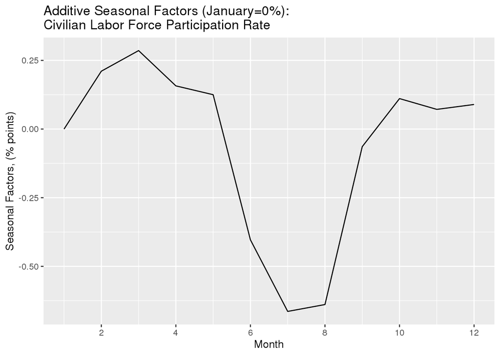

```r
# extract seasonal coefs from model
seasfactors=seasonal$coefficients[2:13]

# manually set coef for January
names(seasfactors)[[1]]='season1'
seasfactors[[1]]=0

# convert to ts object and autoplot
seasfactors %>% ts(start=1) %>%
  autoplot(xlab='Month',ylab='Seasonal Factors, (% points)',
           main='Additive Seasonal Factors (January=0%):\nCivilian Labor Force Participation Rate')
```

There is a relative increase in civilian labor force participation rate in spring and fall with respect to January, and there is a relative decrease in civilian labor force participation rate in summer with respect to January. The suspected reason for the increase is that spring and fall are the major recruitment periods for firms.

**(c) In order to improve your model, add the trend model from problem 1 to your seasonal model. We will refer to this model as the full model. For the full model, plot the respective residuals vs. fitted values and discuss your observations.**

There are flaws in using a linear trend when we regresses for the seasonal factors: a linear trend just doesn’t fit the data too well. Here we will use the smooth trend which we selected from the previous problem, together with the full set of seasonal dummies, to account for the variations in data. This will hopefully be an improvement to both the estimation of the seasonal factors and the estimation of a full model.

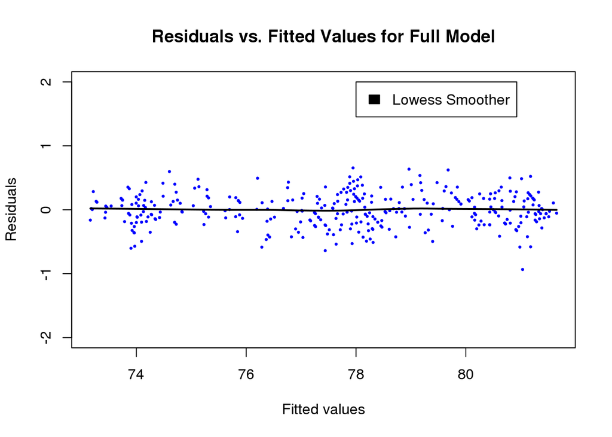

```r
# regress model on more sophisticated trend component and seasonal dummies
full=tslm(Labor~I(t*t)+t*cos(2*pi*t/13)+sin(2*pi*t/13)+season)

# plot the residuals versus the fitted
plot(full$fit,full$res,cex=0.5,pch=20,col='blue',
     xlab='Fitted values',ylab='Residuals',
     main='Residuals vs. Fitted Values for Full Model',
     ylim=c(-2,2))

# plot the lowess smoother curve on top of the residuals
lines(lowess(full$fit,full$res),lwd=2)

# create a legend for the lowess smoother
legend(78,2, c("Lowess Smoother"), fill =c("black"),cex=1,bty="y")
```

At all ranges of fitted values, the residuals look evenly and randomaly distributed on both side of the zero line. The lowess smoother is nearly indistinguishable from the zero line. This means that our model did not miss any pattern in the data. The error looks like it has constant variance, which means we need not worry about heteroskedasticity in the regression process.

**(d) Interpret the respective summary statistics including the error metrics of your full model.**

To evaluate the full model, we look at the statistics form the summary.

```r
# print the summary, aic, and bic
summary(full)
```

```
##
## Call:
## tslm(formula = Labor ~ I(t * t) + t * cos(2 * pi * t/13) + sin(2 *
##     pi * t/13) + season)
##
## Residuals:
##      Min       1Q   Median       3Q      Max
## -0.93373 -0.17131 -0.00317  0.16704  0.65428
##
## Coefficients:
##                        Estimate Std. Error t value Pr(>|t|)
## (Intercept)          -8.814e+03  1.182e+03  -7.456 8.48e-13 ***
## I(t * t)             -2.355e-03  2.937e-04  -8.017 2.07e-14 ***
## t                     9.157e+00  1.179e+00   7.770 1.09e-13 ***
## cos(2 * pi * t/13)    3.453e+01  6.469e+00   5.338 1.79e-07 ***
## sin(2 * pi * t/13)   -1.864e-01  2.176e-02  -8.566 4.63e-16 ***
## season2               2.084e-01  7.090e-02   2.940  0.00352 **
## season3               2.811e-01  7.090e-02   3.965 9.05e-05 ***
## season4               1.502e-01  7.090e-02   2.119  0.03488 *
## season5               1.157e-01  7.090e-02   1.632  0.10368
## season6              -4.153e-01  7.090e-02  -5.857 1.17e-08 ***
## season7              -6.784e-01  7.091e-02  -9.568  < 2e-16 ***
## season8              -6.559e-01  7.091e-02  -9.249  < 2e-16 ***
## season9              -8.334e-02  7.091e-02  -1.175  0.24079
## season10              8.917e-02  7.092e-02   1.257  0.20953
## season11              4.738e-02  7.092e-02   0.668  0.50459
## season12              6.272e-02  7.093e-02   0.884  0.37723
## t:cos(2 * pi * t/13) -1.741e-02  3.224e-03  -5.401 1.30e-07 ***
## ---
## Signif. codes:  0 '***' 0.001 '**' 0.01 '*' 0.05 '.' 0.1 ' ' 1
##
## Residual standard error: 0.2653 on 319 degrees of freedom
## Multiple R-squared:  0.9892, Adjusted R-squared:  0.9887
## F-statistic:  1827 on 16 and 319 DF,  p-value: < 2.2e-16
```

```r
AIC(full)
```

```
## [1] 80.34325
```

```r
BIC(full)
```

```
## [1] 149.0512
```

Out of all the explanatory variables, only the seasonal dummies for season5, season9, season10, season11, season12 are not significant at 5% level. This means that these seasons do not contribute much to explaining the seasonal variation of the data. The aic and bic values are lower than any of the previous models, meaning that including seasonal effects is crucial to explaining the variations of the data. The $R^2_{\mathrm{adj}}$ increased from the seasonal plus linear trend model, indicating that the trend from problem 1 fits the data better than a naive linear trend.

**(e) Use the full model to forecast h-steps (at least 16) ahead. Your forecast should include the respective prediction interval.**

Given the full model which seems to fit existing data well, we attempt to extract forecasts 60 periods ahead ($h=60$), in order to evaluate the degree to which the forecasted values for civilian labor force participation rate is probable.

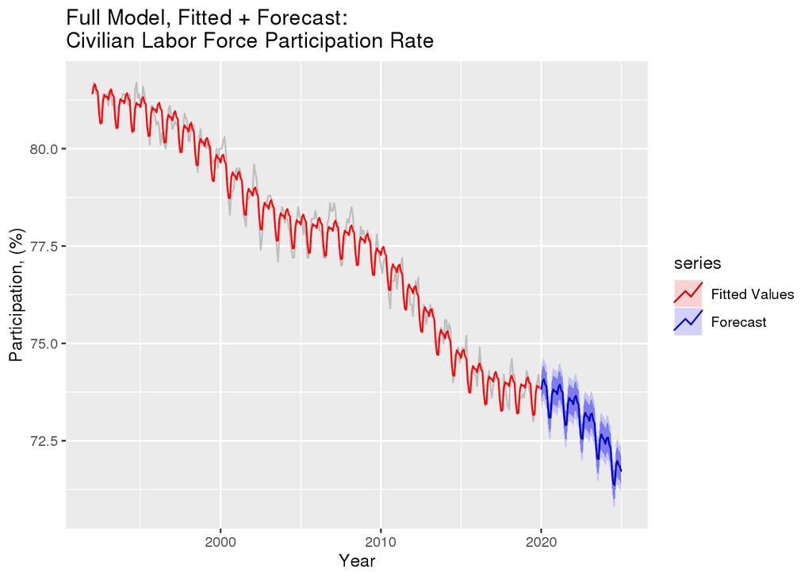

```r
# construct new data to base forecast on
newt=seq(2020,2025,1/12)
newdata=data.frame(newt,cos(2*pi*newt/13),sin(2*pi*newt/13))
names(newdata)=c('t','cos(2 * pi * t/13)','sin(2 * pi * t/13)')

# embed forecast in plots
autoplot(Labor,col='grey',
         main='Full Model, Fitted + Forecast:\nCivilian Labor Force Participation Rate')+
  xlab('Year')+ylab('Participation, (%)')+
  autolayer(full$fitted.values,series='Fitted Values')+
  autolayer(forecast(full,newdata=newdata),series='Forecast')+
  scale_color_manual(values=c('red','blue'),
                     breaks=c('Fitted Values','Forecast'))
```

The figure above shows the forecast of the full model, with an $h=60$ point and interval forecasts. The grey series is the observed data. The lighter shade corresponds to 95% forecast interval and the darker blue shade corresponds to 80% forecast interval. Notable features of the forecast: visually it seems to be a natrual extension to the data. The downward curviness is a result of the estimated cycle. Seasonality is cleary present in the forecasts. The size of the prediction interval sees to be in agreement with the amount that actual data (grey) deviates from the fitted values.

We must note that the prediction interval which `forecast` produces must be taken with a grain of salt. This prediction interval does not take into account the error introduced when estimating the model parameters. Adding to that, the error in the cycle period is unaccountable given that we have dictated the period to be 13 based on trial and error. The true prediction interval should be larger.

## III. Conclusions and Future Work (state your conclusion regarding your final model and forecast, and provide some insight as to how it could be improved).

To model the evolution of the civilian labor force participation rate (Bachelor’s degree and higher, 25 years and over), our final chosen model is
$$LABOR_t=\beta_0+\beta_1TIME_t+\beta_2TIME^2_t+(A_0+A_1TIME_t)\cos\left(\frac{2\pi}{13}TIME_t\right)+B_0\sin\left(\frac{2\pi}{13}TIME_t\right)+\sum_{m=2}^{12}\delta_mMONTH_{mt}$$
The first three terms in the model account for a quatratic trend. The next two terms account for a amplitude-varying 13 year cycle. The last term accounts for seasonality.

The result of the full model regression is as follows:

1. The regression produced a quadratic trend which concaves down, suggesting that the decrease in the labor force participation rate is accelerating. This seems to be related to the recent advances in production technologies, whose potential to replace human labor continues to rise.
2. The data is modulated by a ~13 year cycle, whose amplitude is slowly increasing (on the scale of 0.01-0.02 percentage points per year). This is possibly related to the expansions and recessions of the business cycle. The dynamics of the cycle seems destabilize as the quadratic trend rapidly throws it downward.
3. The seasonal part of the model suggests that the labor force participation rate is lower than average in summer and higher than average in spring and fall, which could be related to how businesses manages recruitment and cuts logistically.

Based on these observations, the model forecasts that in the short run (5 years, $h=60$):

1. The decrease in labor force participation rate will continue to speed up. Extrapolating onto a grander timescale, people could be less incentivized to provide labor, and there could be a shift towards less labor intensive industries.
2. The recession part of the business cycle will dominate the short run contraction of the labor force participation rate.
3. The seasonal variation will persist on top of the trend and cycle.

**Future work:** There are several points where our model could improve: 1. A lack of longtidutinal data: our model used civilian labor force participation rate from 1992 to 2019, some 28 years of data. If we could obtain the data from beyond 1992, we could verify whether the quadratic trend, the 13-year business cycle, and the roughly-constant seasonality are characteristics which persists in the long run, or they are themselves time-varying. With longer-term data, perhaps other trends and cycles are more appropriate. 2. A lack of latitudinal data: our model used data from the U.S. only, and we only included the civilian labor force participation rate of the people who has Bachelor’s degree and higher and are 25 years and over. If we obtained data from other subcategories of the population, and even other countries, we can verify whether or not the dynamics we see in our model is specific to the population and country. 3. Seasonality assumed constant throughout the 28 years of data: This assumption is an artifact of the regression model we used. To verify whether this assumption is true and improve the model, it is advisable to perform seasonal decomposition with algorithms such as STL, X11, or SEATS. 4. Residuals assumed to be independent: we have not checked for serial correlation in the residuals of the full model. If there were serial correlation, an ARMA model would perhaps be appropriate.

## IV. References

Civilian Labor Force Participation Rate: Bachelor’s Degree and Higher, 25 years and over (LNU01327662), *FRED Economic Data*, accessed Jan 27, 2020, available at: https://fred.stlouisfed.org/series/LNU01327662